# TensolFlow

## base

### Tensorという形式でデータを保持する。

```python
import tensorflow as tf
import numpy as np

# それぞれ定数を定義
a = tf.constant(1)
b = tf.constant(2, dtype=tf.float32, shape=[3,2])
c = tf.constant(np.arange(4), dtype=tf.float32, shape=[2,2])

print('a:', a)
print('b:', b)
print('c:', c)
```

```
a: Tensor("Const:0", shape=(), dtype=int32)
b: Tensor("Const_1:0", shape=(3, 2), dtype=float32)
c: Tensor("Const_2:0", shape=(2, 2), dtype=float32)
```

### Session.run(a)すると、runしたノードaに関連するノードをすべて計算し、出力される。

```python
sess = tf.Session()

print('a:', sess.run(a))
print('b:', sess.run(b))
print('c:', sess.run(c))

z=sess.run(a)
print(z*2)
```

```
a: 1
b: [[2. 2.]
 [2. 2.]
 [2. 2.]]
c: [[0. 1.]
 [2. 3.]]
2
```

### placeholder

```python
# プレースホルダーを定義
x = tf.placeholder(dtype=tf.float32, shape=[None,3])

print('x:', x)

sess = tf.Session()

X = np.random.rand(2,3)
print('X(numpy):', X)
```

```
x: Tensor("Placeholder:0", shape=(?, 3), dtype=float32)
X(numpy): [[0.83370985 0.4860043  0.98081105]
 [0.06851552 0.4632204  0.93428418]]
```

```python
# プレースホルダにX[0]を入力
# shapeを(3,)から(1,3)にするためreshape
print('x:', sess.run(x, feed_dict={x:X[0].reshape(1,-1)}))
```

```
x: [[0.83370984 0.4860043  0.98081106]]
```

```python
# プレースホルダにX[1]を入力
print('x:', sess.run(x, feed_dict={x:X[1].reshape(1,-1)}))
```

```
x: [[0.06851552 0.4632204  0.9342842 ]]
```

### variables

```python
# 定数を定義
a = tf.constant(10)
print('a:', a)
# 変数を定義
x = tf.Variable(1)
print('x:', x)

calc_op = x * a
print(calc_op)

# xの値を更新
update_x = tf.assign(x, calc_op)
print(update_x)
```

```
a: Tensor("Const_3:0", shape=(), dtype=int32)
WARNING:tensorflow:From C:\ProgramData\Anaconda3\lib\site-packages\tensorflow\python\framework\op_def_library.py:263: colocate_with (from tensorflow.python.framework.ops) is deprecated and will be removed in a future version.
Instructions for updating:
Colocations handled automatically by placer.
x: <tf.Variable 'Variable:0' shape=() dtype=int32_ref>
Tensor("mul:0", shape=(), dtype=int32)
Tensor("Assign:0", shape=(), dtype=int32_ref)
```

```python
sess = tf.Session()

# 変数の初期化
init = tf.global_variables_initializer()
sess.run(init)

print(sess.run(x))

sess.run(update_x)
print(sess.run(x))

sess.run(update_x)
print(sess.run(x))
```

```
1
10
100
```

## 線形回帰

```python
import numpy as np
import tensorflow as tf
import matplotlib.pyplot as plt

iters_num = 300
plot_interval = 10

# データを生成
n = 100
x = np.random.randn(n)#小数の乱数
d = 3 * x + 2

# ノイズを加える
noise = 0.3
d = d + noise * np.random.randn(n)

print(x)
```

```
[-1.54694948 -1.51921087  1.57037751  0.44242968  0.93837436 -1.12738744
 -1.30564086 -1.15317279  0.64632078  0.28184709  0.16976725 -0.04971216
  1.94835533 -0.06157433  0.21539213 -1.25684201  0.4468912   1.70219375
  0.21418637 -0.55039244 -1.18742887  1.16456899 -0.61855652  0.243373
  1.7951167  -1.18503724 -0.43109097  1.1094946   0.45238567  0.9242078
  0.12603835  1.26608628 -0.52972964  0.94286854  0.72474552 -0.01722734
  0.71382974  1.13459924 -0.70918891 -0.48249614 -1.26960039  0.13389292
  0.29250417 -0.11003267 -0.5317991   1.94502461  0.46864993  2.49999654
  1.19651059  0.69394048 -0.39563418  0.50650395  0.244284    1.91082568
  0.53858643 -1.32792827 -0.74594445  0.98002203  0.24095125 -1.07468647
  1.42321709  0.9552136   1.53745317  0.60445825  0.82919331 -1.40468116
  1.76418517  2.0902926   1.36217312 -0.67305506  0.92075485  1.55413754
 -1.05193381 -0.35954757 -0.84891241  0.91933351 -1.14127111  0.64555559
  0.05119954  1.64323538  0.04646646  1.15375947 -0.10931806 -0.82747958
 -2.10189543  1.0401296   0.05235331 -0.16250072 -1.20193001 -1.37029845
 -0.19845659  1.0793981  -1.7268737  -0.9387706  -1.147529   -1.42429152
 -0.96081795 -0.49691695 -0.76544498 -0.18550394]
```

```python
# 入力値（プレースホルダー）
xt = tf.placeholder(tf.float32)
dt = tf.placeholder(tf.float32)

# 最適化の対象の変数を初期化
W = tf.Variable(tf.zeros([1]))
b = tf.Variable(tf.zeros([1]))

y = W * xt + b

print(xt)
print(dt)
```

```
Tensor("Placeholder_48:0", dtype=float32)
Tensor("Placeholder_49:0", dtype=float32)
```

```python
# 誤差関数 平均2乗誤差
loss = tf.reduce_mean(tf.square(y - dt))#reduce_meanは平均処理
optimizer = tf.train.GradientDescentOptimizer(0.1)#勾配降下法、学習率0.1、optimizer最適化アルゴリズム
train = optimizer.minimize(loss)#損失関数の最小化

# 初期化
init = tf.global_variables_initializer()
sess = tf.Session()
sess.run(init)
```

```
Generation: 10. 誤差 = 0.16891193
Generation: 20. 誤差 = 0.10064526
Generation: 30. 誤差 = 0.10034347
Generation: 40. 誤差 = 0.10034214
Generation: 50. 誤差 = 0.100342125
Generation: 60. 誤差 = 0.10034214
Generation: 70. 誤差 = 0.10034214
Generation: 80. 誤差 = 0.10034214
Generation: 90. 誤差 = 0.10034214
Generation: 100. 誤差 = 0.10034214
Generation: 110. 誤差 = 0.10034214
Generation: 120. 誤差 = 0.10034214
Generation: 130. 誤差 = 0.10034214
Generation: 140. 誤差 = 0.10034214
Generation: 150. 誤差 = 0.10034214
Generation: 160. 誤差 = 0.10034214
Generation: 170. 誤差 = 0.10034214
Generation: 180. 誤差 = 0.10034214
Generation: 190. 誤差 = 0.10034214
Generation: 200. 誤差 = 0.10034214
Generation: 210. 誤差 = 0.10034214
Generation: 220. 誤差 = 0.10034214
Generation: 230. 誤差 = 0.10034214
Generation: 240. 誤差 = 0.10034214
Generation: 250. 誤差 = 0.10034214
Generation: 260. 誤差 = 0.10034214
Generation: 270. 誤差 = 0.10034214
Generation: 280. 誤差 = 0.10034214
Generation: 290. 誤差 = 0.10034214
Generation: 300. 誤差 = 0.10034214
[2.9889605]
[2.041801]
```

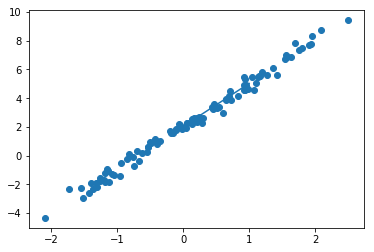

```python
# 作成したデータをトレーニングデータとして準備
x_train = x.reshape(-1,1)
d_train = d.reshape(-1,1)#訓練用ラベル

# トレーニング
for i in range(iters_num):#反復回数
    sess.run(train, feed_dict={xt:x_train,dt:d_train})#訓練実行
    if (i+1) % plot_interval == 0:
        loss_val = sess.run(loss, feed_dict={xt:x_train,dt:d_train})
        W_val = sess.run(W)
        b_val = sess.run(b)
        print('Generation: ' + str(i+1) + '. 誤差 = ' + str(loss_val))

print(W_val)
print(b_val)

#  予測関数
def predict(x):
    return W_val * x + b_val

fig = plt.figure()
subplot = fig.add_subplot(1, 1, 1)
plt.scatter(x, d)
linex = np.linspace(0, 1, 2)
liney = predict(linex)
subplot.plot(linex,liney)
plt.show()
```

### [try]

- noiseの値を変更しよう(noise 0.3を0.03に変更）

```
Generation: 10. 誤差 = 0.17103556
Generation: 20. 誤差 = 0.10534405
Generation: 30. 誤差 = 0.07941533
Generation: 40. 誤差 = 0.05995369
Generation: 50. 誤差 = 0.045305546
Generation: 60. 誤差 = 0.034280248
Generation: 70. 誤差 = 0.025981836
Generation: 80. 誤差 = 0.019735824
Generation: 90. 誤差 = 0.01503463
Generation: 100. 誤差 = 0.011496145
Generation: 110. 誤差 = 0.008832831
Generation: 120. 誤差 = 0.0068282373
Generation: 130. 誤差 = 0.005319431
Generation: 140. 誤差 = 0.0041837976
Generation: 150. 誤差 = 0.003329029
Generation: 160. 誤差 = 0.0026856798
Generation: 170. 誤差 = 0.002201438
Generation: 180. 誤差 = 0.0018369699
Generation: 190. 誤差 = 0.0015626396
Generation: 200. 誤差 = 0.001356159
Generation: 210. 誤差 = 0.0012007478
Generation: 220. 誤差 = 0.0010837722
Generation: 230. 誤差 = 0.0009957276
Generation: 240. 誤差 = 0.0009294575
Generation: 250. 誤差 = 0.00087957934
Generation: 260. 誤差 = 0.0008420385
Generation: 270. 誤差 = 0.0008137801
Generation: 280. 誤差 = 0.000792513
Generation: 290. 誤差 = 0.00077650486
Generation: 300. 誤差 = 0.0007644552
[2.9944782]
[1.9983674]
```

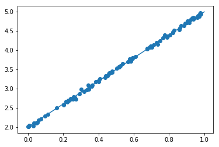

```python
iters_num = 300
plot_interval = 10

# データを生成
n = 100
x = np.random.rand(n)
d = 3 * x + 2

# ノイズを加える
noise = 0.03
d = d + noise * np.random.randn(n)

# 入力値
xt = tf.placeholder(tf.float32)
dt = tf.placeholder(tf.float32)

# 最適化の対象の変数を初期化
W = tf.Variable(tf.zeros([1]))
b = tf.Variable(tf.zeros([1]))

y = W * xt + b

# 誤差関数 平均2乗誤差
loss = tf.reduce_mean(tf.square(y - dt))
optimizer = tf.train.GradientDescentOptimizer(0.1)
train = optimizer.minimize(loss)

# 初期化
init = tf.global_variables_initializer()
sess = tf.Session()
sess.run(init)

# 作成したデータをトレーニングデータとして準備
x_train = x.reshape(-1,1)
d_train = d.reshape(-1,1)

# トレーニング
for i in range(iters_num):
    sess.run(train, feed_dict={xt:x_train,dt:d_train})
    if (i+1) % plot_interval == 0:
        loss_val = sess.run(loss, feed_dict={xt:x_train,dt:d_train})
        W_val = sess.run(W)
        b_val = sess.run(b)
        print('Generation: ' + str(i+1) + '. 誤差 = ' + str(loss_val))

print(W_val)
print(b_val)

#  予測関数
def predict(x):
    return W_val * x + b_val

fig = plt.figure()
subplot = fig.add_subplot(1, 1, 1)
plt.scatter(x, d)
linex = np.linspace(0, 1, 2)
liney = predict(linex)
subplot.plot(linex,liney)
plt.show()
```

### [try]

- dの数値を変更しよう (d=3x+2をd=30x+2に変更）

```
Generation: 10. 誤差 = 8.645359
Generation: 20. 誤差 = 0.1549129
Generation: 30. 誤差 = 0.0781575
Generation: 40. 誤差 = 0.07746361
Generation: 50. 誤差 = 0.077457316
Generation: 60. 誤差 = 0.077457145
Generation: 70. 誤差 = 0.07745706
Generation: 80. 誤差 = 0.07745706
Generation: 90. 誤差 = 0.07745706
Generation: 100. 誤差 = 0.07745706
Generation: 110. 誤差 = 0.07745706
Generation: 120. 誤差 = 0.07745706
Generation: 130. 誤差 = 0.07745706
Generation: 140. 誤差 = 0.07745706
Generation: 150. 誤差 = 0.07745706
Generation: 160. 誤差 = 0.07745706
Generation: 170. 誤差 = 0.07745706
Generation: 180. 誤差 = 0.07745706
Generation: 190. 誤差 = 0.07745706
Generation: 200. 誤差 = 0.07745706
Generation: 210. 誤差 = 0.07745706
Generation: 220. 誤差 = 0.07745706
Generation: 230. 誤差 = 0.07745706
Generation: 240. 誤差 = 0.07745706
Generation: 250. 誤差 = 0.07745706
Generation: 260. 誤差 = 0.07745706
Generation: 270. 誤差 = 0.07745706
Generation: 280. 誤差 = 0.07745706
Generation: 290. 誤差 = 0.07745706
Generation: 300. 誤差 = 0.07745706
[30.003994]
[1.9790144]
```

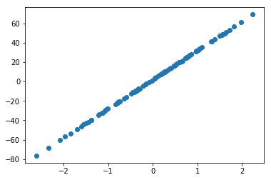

```python
iters_num = 300
plot_interval = 10

# データを生成
n = 100
x = np.random.randn(n)
d = 30 * x + 2

# ノイズを加える
noise = 0.3
d = d + noise * np.random.randn(n)

# 入力値
xt = tf.placeholder(tf.float32)
dt = tf.placeholder(tf.float32)

# 最適化の対象の変数を初期化
W = tf.Variable(tf.zeros([1]))
b = tf.Variable(tf.zeros([1]))

y = W * xt + b

# 誤差関数 平均2乗誤差
loss = tf.reduce_mean(tf.square(y - dt))
optimizer = tf.train.GradientDescentOptimizer(0.1)
train = optimizer.minimize(loss)

# 初期化
init = tf.global_variables_initializer()
sess = tf.Session()
sess.run(init)

# 作成したデータをトレーニングデータとして準備
x_train = x.reshape(-1,1)
d_train = d.reshape(-1,1)

# トレーニング
for i in range(iters_num):
    sess.run(train, feed_dict={xt:x_train,dt:d_train})
    if (i+1) % plot_interval == 0:
        loss_val = sess.run(loss, feed_dict={xt:x_train,dt:d_train})
        W_val = sess.run(W)
        b_val = sess.run(b)
        print('Generation: ' + str(i+1) + '. 誤差 = ' + str(loss_val))

print(W_val)
print(b_val)

#  予測関数
def predict(x):
    return W_val * x + b_val

fig = plt.figure()
subplot = fig.add_subplot(1, 1, 1)
plt.scatter(x, d)
linex = np.linspace(0, 1, 2)
liney = predict(linex)
subplot.plot(linex,liney)
plt.show()
```

## 非線形回帰

```
Generation: 100. 誤差 = 26.545837
Generation: 200. 誤差 = 22.251637
Generation: 300. 誤差 = 18.533943
Generation: 400. 誤差 = 15.338687
Generation: 500. 誤差 = 12.613826
Generation: 600. 誤差 = 10.309445
Generation: 700. 誤差 = 8.377865
Generation: 800. 誤差 = 6.7738466
Generation: 900. 誤差 = 5.4547877
Generation: 1000. 誤差 = 4.380972
Generation: 1100. 誤差 = 3.515791
Generation: 1200. 誤差 = 2.8259377
Generation: 1300. 誤差 = 2.2815566
Generation: 1400. 誤差 = 1.8563008
Generation: 1500. 誤差 = 1.527305
Generation: 1600. 誤差 = 1.2750434
Generation: 1700. 誤差 = 1.083127
Generation: 1800. 誤差 = 0.9380164
Generation: 1900. 誤差 = 0.8286844
Generation: 2000. 誤差 = 0.7463011
Generation: 2100. 誤差 = 0.6838835
Generation: 2200. 誤差 = 0.6359978
Generation: 2300. 誤差 = 0.59847856
Generation: 2400. 誤差 = 0.5681932
Generation: 2500. 誤差 = 0.54283065
Generation: 2600. 誤差 = 0.52072835
Generation: 2700. 誤差 = 0.5007215
Generation: 2800. 誤差 = 0.4820201
Generation: 2900. 誤差 = 0.46410888
Generation: 3000. 誤差 = 0.4466671
Generation: 3100. 誤差 = 0.42950803
Generation: 3200. 誤差 = 0.41253242
Generation: 3300. 誤差 = 0.3956974
Generation: 3400. 誤差 = 0.3789939
Generation: 3500. 誤差 = 0.3624318
Generation: 3600. 誤差 = 0.3460315
Generation: 3700. 誤差 = 0.32981813
Generation: 3800. 誤差 = 0.3138184
Generation: 3900. 誤差 = 0.29805923
Generation: 4000. 誤差 = 0.2825663
```

[output cut: 49 more lines]

```
Generation: 9000. 誤差 = 0.0019065297
Generation: 9100. 誤差 = 0.0019000337
Generation: 9200. 誤差 = 0.001896099
Generation: 9300. 誤差 = 0.0018937829
Generation: 9400. 誤差 = 0.0018924671
Generation: 9500. 誤差 = 0.001891742
Generation: 9600. 誤差 = 0.001891348
Generation: 9700. 誤差 = 0.0018911499
Generation: 9800. 誤差 = 0.001891051
Generation: 9900. 誤差 = 0.0018910011
Generation: 10000. 誤差 = 0.0018909833
[[-0.3999309]
 [ 1.5972086]
 [-2.80164  ]
 [ 1.0043371]]
```

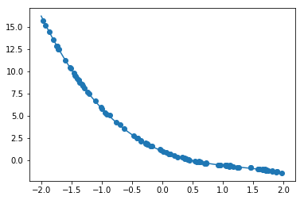

```python
import numpy as np
import tensorflow as tf
import matplotlib.pyplot as plt

iters_num = 10000
plot_interval = 100

# データを生成
n=100
x = np.random.rand(n).astype(np.float32) * 4 - 2
d =  - 0.4 * x ** 3 + 1.6 * x ** 2 - 2.8 * x + 1

#  ノイズを加える
noise = 0.05
d = d + noise * np.random.randn(n)

# モデル
# bを使っていないことに注意.
xt = tf.placeholder(tf.float32, [None, 4])
dt = tf.placeholder(tf.float32, [None, 1])
W = tf.Variable(tf.random_normal([4, 1], stddev=0.01))
y = tf.matmul(xt,W)

# 誤差関数 平均２乗誤差
loss = tf.reduce_mean(tf.square(y - dt))
optimizer = tf.train.AdamOptimizer(0.001)
train = optimizer.minimize(loss)

# 初期化
init = tf.global_variables_initializer()
sess = tf.Session()
sess.run(init)

# 作成したデータをトレーニングデータとして準備
d_train = d.reshape(-1,1)
x_train = np.zeros([n, 4])
for i in range(n):
    for j in range(4):
        x_train[i, j] = x[i]**j

#  トレーニング
for i in range(iters_num):
    if (i+1) % plot_interval == 0:
        loss_val = sess.run(loss, feed_dict={xt:x_train, dt:d_train})
        W_val = sess.run(W)
        print('Generation: ' + str(i+1) + '. 誤差 = ' + str(loss_val))
    sess.run(train, feed_dict={xt:x_train,dt:d_train})

print(W_val[::-1])

# 予測関数
def predict(x):
    result = 0.
    for i in range(0,4):
        result += W_val[i,0] * x ** i
    return result

fig = plt.figure()
subplot = fig.add_subplot(1,1,1)
plt.scatter(x ,d)
linex = np.linspace(-2,2,100)
liney = predict(linex)
subplot.plot(linex,liney)
plt.show()
```

### [try]

- noiseの値を変更しよう(0.05を1に変更）

```
Generation: 100. 誤差 = 21.640308
Generation: 200. 誤差 = 18.205376
Generation: 300. 誤差 = 15.24938
Generation: 400. 誤差 = 12.723288
Generation: 500. 誤差 = 10.580398
Generation: 600. 誤差 = 8.776509
Generation: 700. 誤差 = 7.270082
Generation: 800. 誤差 = 6.0224476
Generation: 900. 誤差 = 4.997961
Generation: 1000. 誤差 = 4.1641345
Generation: 1100. 誤差 = 3.4916868
Generation: 1200. 誤差 = 2.9545393
Generation: 1300. 誤差 = 2.5297062
Generation: 1400. 誤差 = 2.1971385
Generation: 1500. 誤差 = 1.939532
Generation: 1600. 誤差 = 1.7420802
Generation: 1700. 誤差 = 1.5922426
Generation: 1800. 誤差 = 1.4795123
Generation: 1900. 誤差 = 1.3951956
Generation: 2000. 誤差 = 1.3322101
Generation: 2100. 誤差 = 1.2848932
Generation: 2200. 誤差 = 1.2488123
Generation: 2300. 誤差 = 1.2205856
Generation: 2400. 誤差 = 1.1976997
Generation: 2500. 誤差 = 1.1783452
Generation: 2600. 誤差 = 1.1612641
Generation: 2700. 誤差 = 1.1456128
Generation: 2800. 誤差 = 1.1308494
Generation: 2900. 誤差 = 1.1166435
Generation: 3000. 誤差 = 1.1028062
Generation: 3100. 誤差 = 1.0892389
Generation: 3200. 誤差 = 1.0758988
Generation: 3300. 誤差 = 1.0627748
Generation: 3400. 誤差 = 1.0498741
Generation: 3500. 誤差 = 1.0372111
Generation: 3600. 誤差 = 1.0248044
Generation: 3700. 誤差 = 1.0126725
Generation: 3800. 誤差 = 1.0008332
Generation: 3900. 誤差 = 0.9893027
Generation: 4000. 誤差 = 0.97809494
```

[output cut: 49 more lines]

```
Generation: 9000. 誤差 = 0.805887
Generation: 9100. 誤差 = 0.8058862
Generation: 9200. 誤差 = 0.80588603
Generation: 9300. 誤差 = 0.8058857
Generation: 9400. 誤差 = 0.8058856
Generation: 9500. 誤差 = 0.8058856
Generation: 9600. 誤差 = 0.80588555
Generation: 9700. 誤差 = 0.8058856
Generation: 9800. 誤差 = 0.8058855
Generation: 9900. 誤差 = 0.80588555
Generation: 10000. 誤差 = 0.8058856
[[-0.4597927]
 [ 1.578666 ]
 [-2.5477927]
 [ 0.9510553]]
```

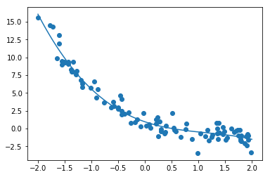

```python
iters_num = 10000
plot_interval = 100

    # データを生成
n=100
x = np.random.rand(n).astype(np.float32) * 4 - 2
d =  - 0.4 * x ** 3 + 1.6 * x ** 2 - 2.8 * x + 1

#  ノイズを加える
noise = 1
d = d + noise * np.random.randn(n)

# モデル
# bを使っていないことに注意.
xt = tf.placeholder(tf.float32, [None, 4])
dt = tf.placeholder(tf.float32, [None, 1])
W = tf.Variable(tf.random_normal([4, 1], stddev=0.01))
y = tf.matmul(xt,W)

# 誤差関数 平均２乗誤差
loss = tf.reduce_mean(tf.square(y - dt))
optimizer = tf.train.AdamOptimizer(0.001)
train = optimizer.minimize(loss)

# 初期化
init = tf.global_variables_initializer()
sess = tf.Session()
sess.run(init)

# 作成したデータをトレーニングデータとして準備
d_train = d.reshape(-1,1)
x_train = np.zeros([n, 4])
for i in range(n):
    for j in range(4):
        x_train[i, j] = x[i]**j

#  トレーニング
for i in range(iters_num):
    if (i+1) % plot_interval == 0:
        loss_val = sess.run(loss, feed_dict={xt:x_train, dt:d_train})
        W_val = sess.run(W)
        print('Generation: ' + str(i+1) + '. 誤差 = ' + str(loss_val))
    sess.run(train, feed_dict={xt:x_train,dt:d_train})

print(W_val[::-1])

# 予測関数
def predict(x):
    result = 0.
    for i in range(0,4):
        result += W_val[i,0] * x ** i
    return result

fig = plt.figure()
subplot = fig.add_subplot(1,1,1)
plt.scatter(x ,d)
linex = np.linspace(-2,2,100)
liney = predict(linex)
subplot.plot(linex,liney)
plt.show()
```

### [try]

- dの数値を変更しよう

(変更前）d = - 0.4 *x ** 3 + 1.6* x **2 - 2.8 *x + 1 (変更後）d = 0.4* x** 3 + 1.6 *x ** 2 - 2.8* x + 1

```
Generation: 100. 誤差 = 16.858486
Generation: 200. 誤差 = 13.833863
Generation: 300. 誤差 = 11.420864
Generation: 400. 誤差 = 9.5036955
Generation: 500. 誤差 = 7.976492
Generation: 600. 誤差 = 6.7478223
Generation: 700. 誤差 = 5.7439466
Generation: 800. 誤差 = 4.9096203
Generation: 900. 誤差 = 4.206179
Generation: 1000. 誤差 = 3.6077561
Generation: 1100. 誤差 = 3.0970533
Generation: 1200. 誤差 = 2.6618237
Generation: 1300. 誤差 = 2.292502
Generation: 1400. 誤差 = 1.9808923
Generation: 1500. 誤差 = 1.719563
Generation: 1600. 誤差 = 1.5016239
Generation: 1700. 誤差 = 1.3206865
Generation: 1800. 誤差 = 1.1708791
Generation: 1900. 誤差 = 1.0468887
Generation: 2000. 誤差 = 0.94398165
Generation: 2100. 誤差 = 0.8580217
Generation: 2200. 誤差 = 0.78546834
Generation: 2300. 誤差 = 0.7233559
Generation: 2400. 誤差 = 0.6692601
Generation: 2500. 誤差 = 0.6212512
Generation: 2600. 誤差 = 0.57783854
Generation: 2700. 誤差 = 0.537905
Generation: 2800. 誤差 = 0.50064397
Generation: 2900. 誤差 = 0.4654965
Generation: 3000. 誤差 = 0.4320932
Generation: 3100. 誤差 = 0.40020633
Generation: 3200. 誤差 = 0.36970666
Generation: 3300. 誤差 = 0.340531
Generation: 3400. 誤差 = 0.31265804
Generation: 3500. 誤差 = 0.28609
Generation: 3600. 誤差 = 0.26083988
Generation: 3700. 誤差 = 0.23692356
Generation: 3800. 誤差 = 0.21435456
Generation: 3900. 誤差 = 0.19314188
Generation: 4000. 誤差 = 0.17328703
```

[output cut: 49 more lines]

```
Generation: 9000. 誤差 = 0.0022206774
Generation: 9100. 誤差 = 0.00222068
Generation: 9200. 誤差 = 0.002220675
Generation: 9300. 誤差 = 0.0022206767
Generation: 9400. 誤差 = 0.0022206784
Generation: 9500. 誤差 = 0.0022206828
Generation: 9600. 誤差 = 0.0022206819
Generation: 9700. 誤差 = 0.0022206805
Generation: 9800. 誤差 = 0.002220678
Generation: 9900. 誤差 = 0.002220681
Generation: 10000. 誤差 = 0.0022206795
[[ 0.4005766]
 [ 1.5947251]
 [-2.8117151]
 [ 1.0070072]]
```

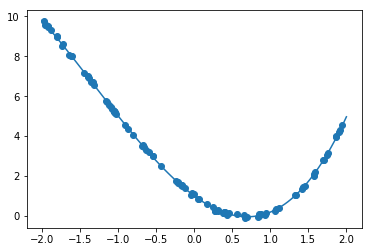

```python
import numpy as np
import tensorflow as tf
import matplotlib.pyplot as plt

iters_num = 10000
plot_interval = 100

# データを生成
n=100
x = np.random.rand(n).astype(np.float32) * 4 - 2
d =  0.4 * x ** 3 + 1.6 * x ** 2 - 2.8 * x + 1

#  ノイズを加える
noise = 0.05
d = d + noise * np.random.randn(n)

# モデル
# bを使っていないことに注意.
xt = tf.placeholder(tf.float32, [None, 4])
dt = tf.placeholder(tf.float32, [None, 1])
W = tf.Variable(tf.random_normal([4, 1], stddev=0.01))
y = tf.matmul(xt,W)

# 誤差関数 平均２乗誤差
loss = tf.reduce_mean(tf.square(y - dt))
optimizer = tf.train.AdamOptimizer(0.001)
train = optimizer.minimize(loss)

# 初期化
init = tf.global_variables_initializer()
sess = tf.Session()
sess.run(init)

# 作成したデータをトレーニングデータとして準備
d_train = d.reshape(-1,1)
x_train = np.zeros([n, 4])
for i in range(n):
    for j in range(4):
        x_train[i, j] = x[i]**j

#  トレーニング
for i in range(iters_num):
    if (i+1) % plot_interval == 0:
        loss_val = sess.run(loss, feed_dict={xt:x_train, dt:d_train})
        W_val = sess.run(W)
        print('Generation: ' + str(i+1) + '. 誤差 = ' + str(loss_val))
    sess.run(train, feed_dict={xt:x_train,dt:d_train})

print(W_val[::-1])

# 予測関数
def predict(x):
    result = 0.
    for i in range(0,4):
        result += W_val[i,0] * x ** i
    return result

fig = plt.figure()
subplot = fig.add_subplot(1,1,1)
plt.scatter(x ,d)
linex = np.linspace(-2,2,100)
liney = predict(linex)
subplot.plot(linex,liney)
plt.show()
```

## [try]

- 次の式をモデルとして回帰を行おう $$ y=30x^{2} +0.5x+0.2 $$

```
Generation: 100. 誤差 = 2658.9
Generation: 200. 誤差 = 2624.853
Generation: 300. 誤差 = 2591.5386
Generation: 400. 誤差 = 2558.9316
Generation: 500. 誤差 = 2527.011
Generation: 600. 誤差 = 2495.7532
Generation: 700. 誤差 = 2465.1367
Generation: 800. 誤差 = 2435.1409
Generation: 900. 誤差 = 2405.7466
Generation: 1000. 誤差 = 2376.9329
Generation: 1100. 誤差 = 2348.682
Generation: 1200. 誤差 = 2320.975
Generation: 1300. 誤差 = 2293.794
Generation: 1400. 誤差 = 2267.1218
Generation: 1500. 誤差 = 2240.9407
Generation: 1600. 誤差 = 2215.235
Generation: 1700. 誤差 = 2189.9873
Generation: 1800. 誤差 = 2165.182
Generation: 1900. 誤差 = 2140.8025
Generation: 2000. 誤差 = 2116.8337
Generation: 2100. 誤差 = 2093.2593
Generation: 2200. 誤差 = 2070.064
Generation: 2300. 誤差 = 2047.2323
Generation: 2400. 誤差 = 2024.7489
Generation: 2500. 誤差 = 2002.5984
Generation: 2600. 誤差 = 1980.765
Generation: 2700. 誤差 = 1959.2339
Generation: 2800. 誤差 = 1937.9894
Generation: 2900. 誤差 = 1917.0167
Generation: 3000. 誤差 = 1896.3007
Generation: 3100. 誤差 = 1875.8263
Generation: 3200. 誤差 = 1855.5793
Generation: 3300. 誤差 = 1835.5457
Generation: 3400. 誤差 = 1815.7119
Generation: 3500. 誤差 = 1796.0654
Generation: 3600. 誤差 = 1776.5948
Generation: 3700. 誤差 = 1757.2894
Generation: 3800. 誤差 = 1738.1394
Generation: 3900. 誤差 = 1719.1375
Generation: 4000. 誤差 = 1700.2762
```

[output cut: 49 more lines]

```
Generation: 9000. 誤差 = 917.8977
Generation: 9100. 誤差 = 905.38947
Generation: 9200. 誤差 = 893.00476
Generation: 9300. 誤差 = 880.7364
Generation: 9400. 誤差 = 868.5899
Generation: 9500. 誤差 = 856.5608
Generation: 9600. 誤差 = 844.6525
Generation: 9700. 誤差 = 832.86127
Generation: 9800. 誤差 = 821.1902
Generation: 9900. 誤差 = 809.63617
Generation: 10000. 誤差 = 798.2025
[[ 4.237667 ]
 [ 9.442325 ]
 [-4.06645  ]
 [ 9.2579775]]
```

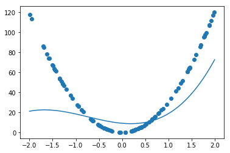

```python
import numpy as np
import tensorflow as tf
import matplotlib.pyplot as plt

iters_num = 10000
plot_interval = 100

# データを生成
n=100
x = np.random.rand(n).astype(np.float32) * 4 - 2
d =  30 * x ** 2 + 0.5 * x + 0.2

#  ノイズを加える
noise = 0.05
d = d + noise * np.random.randn(n)

# モデル
# bを使っていないことに注意.
xt = tf.placeholder(tf.float32, [None, 4])
dt = tf.placeholder(tf.float32, [None, 1])
W = tf.Variable(tf.random_normal([4, 1], stddev=0.01))
y = tf.matmul(xt,W)

# 誤差関数 平均２乗誤差
loss = tf.reduce_mean(tf.square(y - dt))
optimizer = tf.train.AdamOptimizer(0.001)
train = optimizer.minimize(loss)

# 初期化
init = tf.global_variables_initializer()
sess = tf.Session()
sess.run(init)

# 作成したデータをトレーニングデータとして準備
d_train = d.reshape(-1,1)
x_train = np.zeros([n, 4])
for i in range(n):
    for j in range(4):
        x_train[i, j] = x[i]**j

#  トレーニング
for i in range(iters_num):
    if (i+1) % plot_interval == 0:
        loss_val = sess.run(loss, feed_dict={xt:x_train, dt:d_train})
        W_val = sess.run(W)
        print('Generation: ' + str(i+1) + '. 誤差 = ' + str(loss_val))
    sess.run(train, feed_dict={xt:x_train,dt:d_train})

print(W_val[::-1])

# 予測関数
def predict(x):
    result = 0.
    for i in range(0,4):
        result += W_val[i,0] * x ** i
    return result

fig = plt.figure()
subplot = fig.add_subplot(1,1,1)
plt.scatter(x ,d)
linex = np.linspace(-2,2,100)
liney = predict(linex)
subplot.plot(linex,liney)
plt.show()
```

## [try]

- 誤差が収束するようlearning_rateを調整しよう(0.001を0.1に変更。)

```
Generation: 100. 誤差 = 1000.7947
Generation: 200. 誤差 = 338.7539
Generation: 300. 誤差 = 159.625
Generation: 400. 誤差 = 102.543076
Generation: 500. 誤差 = 69.70407
Generation: 600. 誤差 = 45.770912
Generation: 700. 誤差 = 28.660395
Generation: 800. 誤差 = 17.090307
Generation: 900. 誤差 = 9.697431
Generation: 1000. 誤差 = 5.2305775
Generation: 1100. 誤差 = 2.6783893
Generation: 1200. 誤差 = 1.3003355
Generation: 1300. 誤差 = 0.5978639
Generation: 1400. 誤差 = 0.2602947
Generation: 1500. 誤差 = 0.10762539
Generation: 1600. 誤差 = 0.042778827
Generation: 1700. 誤差 = 0.016966928
Generation: 1800. 誤差 = 0.007366726
Generation: 1900. 誤差 = 0.0040382203
Generation: 2000. 誤差 = 0.0029663749
Generation: 2100. 誤差 = 0.0026466073
Generation: 2200. 誤差 = 0.002558667
Generation: 2300. 誤差 = 0.0025364738
Generation: 2400. 誤差 = 0.002531321
Generation: 2500. 誤差 = 0.0025302577
Generation: 2600. 誤差 = 0.0025300742
Generation: 2700. 誤差 = 0.0025300109
Generation: 2800. 誤差 = 0.002530031
Generation: 2900. 誤差 = 0.0025300079
Generation: 3000. 誤差 = 0.002529989
Generation: 3100. 誤差 = 0.0025300074
Generation: 3200. 誤差 = 0.0025300079
Generation: 3300. 誤差 = 0.0025300067
Generation: 3400. 誤差 = 0.0025300083
Generation: 3500. 誤差 = 0.0025300118
Generation: 3600. 誤差 = 0.0025300253
Generation: 3700. 誤差 = 0.0025300323
Generation: 3800. 誤差 = 0.0025300318
Generation: 3900. 誤差 = 0.0025300167
Generation: 4000. 誤差 = 0.0025299883
```

[output cut: 49 more lines]

```
Generation: 9000. 誤差 = 0.002533938
Generation: 9100. 誤差 = 0.002530016
Generation: 9200. 誤差 = 0.0025300095
Generation: 9300. 誤差 = 0.0025318987
Generation: 9400. 誤差 = 0.0025299897
Generation: 9500. 誤差 = 0.0066457605
Generation: 9600. 誤差 = 0.0025300877
Generation: 9700. 誤差 = 0.0025299944
Generation: 9800. 誤差 = 0.00280275
Generation: 9900. 誤差 = 0.0025299934
Generation: 10000. 誤差 = 0.0025299964
[[4.5494391e-03]
 [2.9994068e+01]
 [4.8868811e-01]
 [2.0332426e-01]]
```

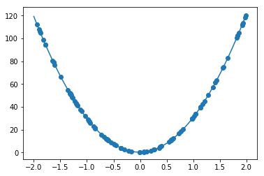

```python
import numpy as np
import tensorflow as tf
import matplotlib.pyplot as plt

iters_num = 10000
plot_interval = 100

# データを生成
n=100
x = np.random.rand(n).astype(np.float32) * 4 - 2
d =  30 * x ** 2 + 0.5 * x + 0.2

#  ノイズを加える
noise = 0.05
d = d + noise * np.random.randn(n)

# モデル
# bを使っていないことに注意.
xt = tf.placeholder(tf.float32, [None, 4])
dt = tf.placeholder(tf.float32, [None, 1])
W = tf.Variable(tf.random_normal([4, 1], stddev=0.01))
y = tf.matmul(xt,W)

# 誤差関数 平均２乗誤差
loss = tf.reduce_mean(tf.square(y - dt))
optimizer = tf.train.AdamOptimizer(0.1)
train = optimizer.minimize(loss)

# 初期化
init = tf.global_variables_initializer()
sess = tf.Session()
sess.run(init)

# 作成したデータをトレーニングデータとして準備
d_train = d.reshape(-1,1)
x_train = np.zeros([n, 4])
for i in range(n):
    for j in range(4):
        x_train[i, j] = x[i]**j

#  トレーニング
for i in range(iters_num):
    if (i+1) % plot_interval == 0:
        loss_val = sess.run(loss, feed_dict={xt:x_train, dt:d_train})
        W_val = sess.run(W)
        print('Generation: ' + str(i+1) + '. 誤差 = ' + str(loss_val))
    sess.run(train, feed_dict={xt:x_train,dt:d_train})

print(W_val[::-1])

# 予測関数
def predict(x):
    result = 0.
    for i in range(0,4):
        result += W_val[i,0] * x ** i
    return result

fig = plt.figure()
subplot = fig.add_subplot(1,1,1)
plt.scatter(x ,d)
linex = np.linspace(-2,2,100)
liney = predict(linex)
subplot.plot(linex,liney)
plt.show()
```

## [try]

- 誤差が収束するようiters_numを調整しよう

```
Generation: 100. 誤差 = 2443.1685
Generation: 200. 誤差 = 2408.7278
Generation: 300. 誤差 = 2375.0154
Generation: 400. 誤差 = 2342.0115
Generation: 500. 誤差 = 2309.6956
Generation: 600. 誤差 = 2278.051
Generation: 700. 誤差 = 2247.0579
Generation: 800. 誤差 = 2216.6995
Generation: 900. 誤差 = 2186.9592
Generation: 1000. 誤差 = 2157.8208
Generation: 1100. 誤差 = 2129.2686
Generation: 1200. 誤差 = 2101.2876
Generation: 1300. 誤差 = 2073.863
Generation: 1400. 誤差 = 2046.9812
Generation: 1500. 誤差 = 2020.6282
Generation: 1600. 誤差 = 1994.7908
Generation: 1700. 誤差 = 1969.4558
Generation: 1800. 誤差 = 1944.6111
Generation: 1900. 誤差 = 1920.2444
Generation: 2000. 誤差 = 1896.3434
Generation: 2100. 誤差 = 1872.8969
Generation: 2200. 誤差 = 1849.8934
Generation: 2300. 誤差 = 1827.3213
Generation: 2400. 誤差 = 1805.17
Generation: 2500. 誤差 = 1783.4285
Generation: 2600. 誤差 = 1762.0853
Generation: 2700. 誤差 = 1741.1306
Generation: 2800. 誤差 = 1720.5535
Generation: 2900. 誤差 = 1700.3433
Generation: 3000. 誤差 = 1680.4893
Generation: 3100. 誤差 = 1660.9811
Generation: 3200. 誤差 = 1641.8081
Generation: 3300. 誤差 = 1622.9594
Generation: 3400. 誤差 = 1604.425
Generation: 3500. 誤差 = 1586.1935
Generation: 3600. 誤差 = 1568.2543
Generation: 3700. 誤差 = 1550.5962
Generation: 3800. 誤差 = 1533.2086
Generation: 3900. 誤差 = 1516.0803
Generation: 4000. 誤差 = 1499.1997
```

[output cut: 449 more lines]

```
Generation: 49000. 誤差 = 0.00245797
Generation: 49100. 誤差 = 0.0024579754
Generation: 49200. 誤差 = 0.0024579468
Generation: 49300. 誤差 = 0.0024579745
Generation: 49400. 誤差 = 0.0024579493
Generation: 49500. 誤差 = 0.0024579572
Generation: 49600. 誤差 = 0.002457943
Generation: 49700. 誤差 = 0.0024579575
Generation: 49800. 誤差 = 0.0024580092
Generation: 49900. 誤差 = 0.0024579528
Generation: 50000. 誤差 = 0.0024580394
[[2.3939405e-03]
 [2.9999142e+01]
 [4.9005434e-01]
 [2.0139773e-01]]
```

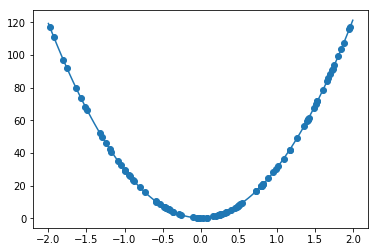

```python
iters_num = 50000
plot_interval = 100

# データを生成
n=100
x = np.random.rand(n).astype(np.float32) * 4 - 2
d =  30 * x ** 2 + 0.5 * x + 0.2

#  ノイズを加える
noise = 0.05
d = d + noise * np.random.randn(n)

# モデル
# bを使っていないことに注意.
xt = tf.placeholder(tf.float32, [None, 4])
dt = tf.placeholder(tf.float32, [None, 1])
W = tf.Variable(tf.random_normal([4, 1], stddev=0.01))
y = tf.matmul(xt,W)

# 誤差関数 平均２乗誤差
loss = tf.reduce_mean(tf.square(y - dt))
optimizer = tf.train.AdamOptimizer(0.001)
train = optimizer.minimize(loss)

# 初期化
init = tf.global_variables_initializer()
sess = tf.Session()
sess.run(init)

# 作成したデータをトレーニングデータとして準備
d_train = d.reshape(-1,1)
x_train = np.zeros([n, 4])
for i in range(n):
    for j in range(4):
        x_train[i, j] = x[i]**j

#  トレーニング
for i in range(iters_num):
    if (i+1) % plot_interval == 0:
        loss_val = sess.run(loss, feed_dict={xt:x_train, dt:d_train})
        W_val = sess.run(W)
        print('Generation: ' + str(i+1) + '. 誤差 = ' + str(loss_val))
    sess.run(train, feed_dict={xt:x_train,dt:d_train})

print(W_val[::-1])

# 予測関数
def predict(x):
    result = 0.
    for i in range(0,4):
        result += W_val[i,0] * x ** i
    return result

fig = plt.figure()
subplot = fig.add_subplot(1,1,1)
plt.scatter(x ,d)
linex = np.linspace(-2,2,100)
liney = predict(linex)
subplot.plot(linex,liney)
plt.show()
```

## 分類1層 (mnist) (入力層→出力層）

## - x：入力値, d：教師データ, W：重み, b：バイアス をそれぞれ定義しよう

[output not shown]

[output cut: 167 more lines]

```
Generation: 93. 正解率 = 0.866
[ True  True  True ...  True False  True]
Generation: 94. 正解率 = 0.8671
[ True  True  True ...  True False  True]
Generation: 95. 正解率 = 0.8668
[ True  True  True ...  True False  True]
Generation: 96. 正解率 = 0.8643
[ True  True  True ...  True False  True]
Generation: 97. 正解率 = 0.8659
[ True  True  True ...  True False  True]
Generation: 98. 正解率 = 0.8656
[ True  True  True ...  True False  True]
Generation: 99. 正解率 = 0.8657
[ True  True  True ...  True False  True]
Generation: 100. 正解率 = 0.8624
```

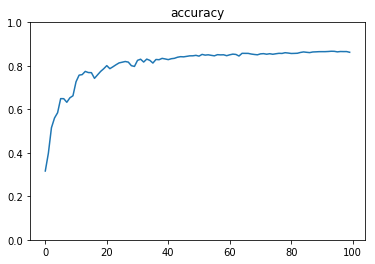

```python
import tensorflow as tf
import matplotlib.pyplot as plt
from tensorflow.examples.tutorials.mnist import input_data
mnist = input_data.read_data_sets("MNIST_data/", one_hot=True)

iters_num = 100
batch_size = 100
plot_interval = 1

# -------------- ここを補填 ------------------------
x = tf.placeholder(tf.float32, [None, 784])
d = tf.placeholder(tf.float32, [None, 10])
W = tf.Variable(tf.random_normal([784, 10], stddev=0.01))
b = tf.Variable(tf.zeros([10]))
# ------------------------------------------------------

y = tf.nn.softmax(tf.matmul(x, W) + b)

# 交差エントロピー
cross_entropy = -tf.reduce_sum(d * tf.log(y), reduction_indices=[1])
loss = tf.reduce_mean(cross_entropy)
train = tf.train.GradientDescentOptimizer(0.1).minimize(loss)

# 正誤を保存
correct = tf.equal(tf.argmax(y, 1), tf.argmax(d, 1))
# 正解率
accuracy = tf.reduce_mean(tf.cast(correct, tf.float32))

init = tf.global_variables_initializer()
sess = tf.Session()
sess.run(init)

accuracies = []
for i in range(iters_num):
    x_batch, d_batch = mnist.train.next_batch(batch_size)
    sess.run(train, feed_dict={x: x_batch, d: d_batch})
    if (i+1) % plot_interval == 0:
        print(sess.run(correct, feed_dict={x: mnist.test.images, d: mnist.test.labels}))
        accuracy_val = sess.run(accuracy, feed_dict={x: mnist.test.images, d: mnist.test.labels})
        accuracies.append(accuracy_val)
        print('Generation: ' + str(i+1) + '. 正解率 = ' + str(accuracy_val))


lists = range(0, iters_num, plot_interval)
plt.plot(lists, accuracies)
plt.title("accuracy")
plt.ylim(0, 1.0)
plt.show()
```

## 分類3層 (mnist) （入力層→中間層→中間層→出力層）

tf.train.GradientDescentOptimizer

```
__init__(
    learning_rate,
    use_locking=False,
    name='GradientDescent'
)
```

tf.train.MomentumOptimizer

```
__init__(
    learning_rate,
    momentum,
    use_locking=False,
    name='Momentum',
    use_nesterov=False
)
```

tf.train.AdagradOptimizer

```
__init__(
    learning_rate,
    initial_accumulator_value=0.1,
    use_locking=False,
    name='Adagrad'
)
```

tf.train.RMSPropOptimizer

```
__init__(
    learning_rate,
    decay=0.9,
    momentum=0.0,
    epsilon=1e-10,
    use_locking=False,
    centered=False,
    name='RMSProp'
)
```

tf.train.AdamOptimizer

```
__init__(
    learning_rate=0.001,
    beta1=0.9,
    beta2=0.999,
    epsilon=1e-08,
    use_locking=False,
    name='Adam'
)
```

```
Extracting MNIST_data/train-images-idx3-ubyte.gz
Extracting MNIST_data/train-labels-idx1-ubyte.gz
Extracting MNIST_data/t10k-images-idx3-ubyte.gz
Extracting MNIST_data/t10k-labels-idx1-ubyte.gz
WARNING:tensorflow:From <ipython-input-21-7595c106b6f4>:31: calling dropout (from tensorflow.python.ops.nn_ops) with keep_prob is deprecated and will be removed in a future version.
Instructions for updating:
Please use `rate` instead of `keep_prob`. Rate should be set to `rate = 1 - keep_prob`.
Generation: 100. 正解率 = 0.116
Generation: 200. 正解率 = 0.2471
Generation: 300. 正解率 = 0.4066
Generation: 400. 正解率 = 0.5313
Generation: 500. 正解率 = 0.6221
Generation: 600. 正解率 = 0.6691
Generation: 700. 正解率 = 0.6994
Generation: 800. 正解率 = 0.7396
Generation: 900. 正解率 = 0.7661
Generation: 1000. 正解率 = 0.7913
Generation: 1100. 正解率 = 0.8118
Generation: 1200. 正解率 = 0.8228
Generation: 1300. 正解率 = 0.839
Generation: 1400. 正解率 = 0.8441
Generation: 1500. 正解率 = 0.857
Generation: 1600. 正解率 = 0.8615
Generation: 1700. 正解率 = 0.8675
Generation: 1800. 正解率 = 0.8746
Generation: 1900. 正解率 = 0.8773
Generation: 2000. 正解率 = 0.882
Generation: 2100. 正解率 = 0.8878
Generation: 2200. 正解率 = 0.8892
Generation: 2300. 正解率 = 0.8919
Generation: 2400. 正解率 = 0.8958
Generation: 2500. 正解率 = 0.8958
Generation: 2600. 正解率 = 0.8975
Generation: 2700. 正解率 = 0.9001
Generation: 2800. 正解率 = 0.9025
Generation: 2900. 正解率 = 0.9045
Generation: 3000. 正解率 = 0.9041
```

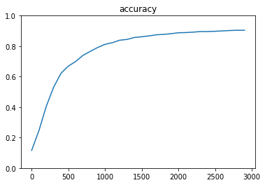

```python
import tensorflow as tf
import numpy as np
from tensorflow.examples.tutorials.mnist import input_data
import matplotlib.pyplot as plt

mnist = input_data.read_data_sets("MNIST_data/", one_hot=True)

iters_num = 3000
batch_size = 100
plot_interval = 100

hidden_layer_size_1 = 600
hidden_layer_size_2 = 300

dropout_rate = 0.5

x = tf.placeholder(tf.float32, [None, 784])
d = tf.placeholder(tf.float32, [None, 10])
W1 = tf.Variable(tf.random_normal([784, hidden_layer_size_1], stddev=0.01))
W2 = tf.Variable(tf.random_normal([hidden_layer_size_1, hidden_layer_size_2], stddev=0.01))
W3 = tf.Variable(tf.random_normal([hidden_layer_size_2, 10], stddev=0.01))

b1 = tf.Variable(tf.zeros([hidden_layer_size_1]))
b2 = tf.Variable(tf.zeros([hidden_layer_size_2]))
b3 = tf.Variable(tf.zeros([10]))

z1 = tf.sigmoid(tf.matmul(x, W1) + b1)
z2 = tf.sigmoid(tf.matmul(z1, W2) + b2)

keep_prob = tf.placeholder(tf.float32)
drop = tf.nn.dropout(z2, keep_prob)

y = tf.nn.softmax(tf.matmul(drop, W3) + b3)
loss = tf.reduce_mean(-tf.reduce_sum(d * tf.log(y), reduction_indices=[1]))


optimizer = tf.train.AdamOptimizer(1e-4)

train = optimizer.minimize(loss)
correct = tf.equal(tf.argmax(y, 1), tf.argmax(d, 1))
accuracy = tf.reduce_mean(tf.cast(correct, tf.float32))

init = tf.global_variables_initializer()
sess = tf.Session()
sess.run(init)

accuracies = []
for i in range(iters_num):
    x_batch, d_batch = mnist.train.next_batch(batch_size)
    sess.run(train, feed_dict={x:x_batch, d:d_batch, keep_prob:(1 - dropout_rate)})
    if (i+1) % plot_interval == 0:
        accuracy_val = sess.run(accuracy, feed_dict={x:mnist.test.images, d:mnist.test.labels, keep_prob:1.0})
        accuracies.append(accuracy_val)
        print('Generation: ' + str(i+1) + '. 正解率 = ' + str(accuracy_val))

lists = range(0, iters_num, plot_interval)
plt.plot(lists, accuracies)
plt.title("accuracy")
plt.ylim(0, 1.0)
plt.show()
```

## [try]

- 隠れ層のサイズを変更してみよう

```
Extracting MNIST_data/train-images-idx3-ubyte.gz
Extracting MNIST_data/train-labels-idx1-ubyte.gz
Extracting MNIST_data/t10k-images-idx3-ubyte.gz
Extracting MNIST_data/t10k-labels-idx1-ubyte.gz
Generation: 100. 正解率 = 0.209
Generation: 200. 正解率 = 0.4502
Generation: 300. 正解率 = 0.6653
Generation: 400. 正解率 = 0.7434
Generation: 500. 正解率 = 0.8048
Generation: 600. 正解率 = 0.8284
Generation: 700. 正解率 = 0.8517
Generation: 800. 正解率 = 0.8642
Generation: 900. 正解率 = 0.8759
Generation: 1000. 正解率 = 0.8814
Generation: 1100. 正解率 = 0.888
Generation: 1200. 正解率 = 0.8901
Generation: 1300. 正解率 = 0.8956
Generation: 1400. 正解率 = 0.8981
Generation: 1500. 正解率 = 0.9018
Generation: 1600. 正解率 = 0.9021
Generation: 1700. 正解率 = 0.9032
Generation: 1800. 正解率 = 0.9066
Generation: 1900. 正解率 = 0.9081
Generation: 2000. 正解率 = 0.9111
Generation: 2100. 正解率 = 0.9114
Generation: 2200. 正解率 = 0.9154
Generation: 2300. 正解率 = 0.915
Generation: 2400. 正解率 = 0.9143
Generation: 2500. 正解率 = 0.9178
Generation: 2600. 正解率 = 0.917
Generation: 2700. 正解率 = 0.9174
Generation: 2800. 正解率 = 0.9213
Generation: 2900. 正解率 = 0.9193
Generation: 3000. 正解率 = 0.9218
```

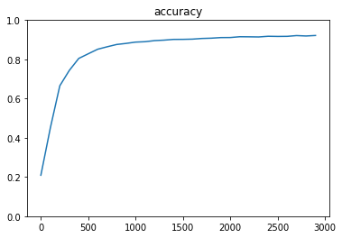

```python
import tensorflow as tf
import numpy as np
from tensorflow.examples.tutorials.mnist import input_data
import matplotlib.pyplot as plt

mnist = input_data.read_data_sets("MNIST_data/", one_hot=True)

iters_num = 3000
batch_size = 100
plot_interval = 100

hidden_layer_size_1 = 1500
hidden_layer_size_2 = 1000

dropout_rate = 0.5

x = tf.placeholder(tf.float32, [None, 784])
d = tf.placeholder(tf.float32, [None, 10])
W1 = tf.Variable(tf.random_normal([784, hidden_layer_size_1], stddev=0.01))
W2 = tf.Variable(tf.random_normal([hidden_layer_size_1, hidden_layer_size_2], stddev=0.01))
W3 = tf.Variable(tf.random_normal([hidden_layer_size_2, 10], stddev=0.01))

b1 = tf.Variable(tf.zeros([hidden_layer_size_1]))
b2 = tf.Variable(tf.zeros([hidden_layer_size_2]))
b3 = tf.Variable(tf.zeros([10]))

z1 = tf.sigmoid(tf.matmul(x, W1) + b1)
z2 = tf.sigmoid(tf.matmul(z1, W2) + b2)

keep_prob = tf.placeholder(tf.float32)
drop = tf.nn.dropout(z2, keep_prob)

y = tf.nn.softmax(tf.matmul(drop, W3) + b3)
loss = tf.reduce_mean(-tf.reduce_sum(d * tf.log(y), reduction_indices=[1]))


optimizer = tf.train.AdamOptimizer(1e-4)

train = optimizer.minimize(loss)
correct = tf.equal(tf.argmax(y, 1), tf.argmax(d, 1))
accuracy = tf.reduce_mean(tf.cast(correct, tf.float32))

init = tf.global_variables_initializer()
sess = tf.Session()
sess.run(init)

accuracies = []
for i in range(iters_num):
    x_batch, d_batch = mnist.train.next_batch(batch_size)
    sess.run(train, feed_dict={x:x_batch, d:d_batch, keep_prob:(1 - dropout_rate)})
    if (i+1) % plot_interval == 0:
        accuracy_val = sess.run(accuracy, feed_dict={x:mnist.test.images, d:mnist.test.labels, keep_prob:1.0})
        accuracies.append(accuracy_val)
        print('Generation: ' + str(i+1) + '. 正解率 = ' + str(accuracy_val))

lists = range(0, iters_num, plot_interval)
plt.plot(lists, accuracies)
plt.title("accuracy")
plt.ylim(0, 1.0)
plt.show()
```

## [try]

- optimizerを変更しよう  
  (AdamをGDに変更)

```
Extracting MNIST_data/train-images-idx3-ubyte.gz
Extracting MNIST_data/train-labels-idx1-ubyte.gz
Extracting MNIST_data/t10k-images-idx3-ubyte.gz
Extracting MNIST_data/t10k-labels-idx1-ubyte.gz
Generation: 100. 正解率 = 0.1009
Generation: 200. 正解率 = 0.1135
Generation: 300. 正解率 = 0.2584
Generation: 400. 正解率 = 0.2434
Generation: 500. 正解率 = 0.4038
Generation: 600. 正解率 = 0.4722
Generation: 700. 正解率 = 0.5675
Generation: 800. 正解率 = 0.705
Generation: 900. 正解率 = 0.7695
Generation: 1000. 正解率 = 0.797
Generation: 1100. 正解率 = 0.8216
Generation: 1200. 正解率 = 0.8287
Generation: 1300. 正解率 = 0.8364
Generation: 1400. 正解率 = 0.8689
Generation: 1500. 正解率 = 0.8741
Generation: 1600. 正解率 = 0.8792
Generation: 1700. 正解率 = 0.8927
Generation: 1800. 正解率 = 0.8947
Generation: 1900. 正解率 = 0.8982
Generation: 2000. 正解率 = 0.8985
Generation: 2100. 正解率 = 0.9055
Generation: 2200. 正解率 = 0.9025
Generation: 2300. 正解率 = 0.9063
Generation: 2400. 正解率 = 0.9025
Generation: 2500. 正解率 = 0.9094
Generation: 2600. 正解率 = 0.9092
Generation: 2700. 正解率 = 0.9124
Generation: 2800. 正解率 = 0.9127
Generation: 2900. 正解率 = 0.8995
Generation: 3000. 正解率 = 0.9159
```

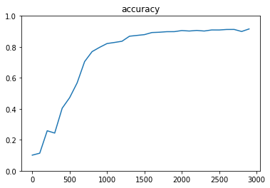

```python
import tensorflow as tf
import numpy as np
from tensorflow.examples.tutorials.mnist import input_data
import matplotlib.pyplot as plt

mnist = input_data.read_data_sets("MNIST_data/", one_hot=True)

iters_num = 3000
batch_size = 100
plot_interval = 100

hidden_layer_size_1 = 600
hidden_layer_size_2 = 300

dropout_rate = 0.5

x = tf.placeholder(tf.float32, [None, 784])
d = tf.placeholder(tf.float32, [None, 10])
W1 = tf.Variable(tf.random_normal([784, hidden_layer_size_1], stddev=0.01))
W2 = tf.Variable(tf.random_normal([hidden_layer_size_1, hidden_layer_size_2], stddev=0.01))
W3 = tf.Variable(tf.random_normal([hidden_layer_size_2, 10], stddev=0.01))

b1 = tf.Variable(tf.zeros([hidden_layer_size_1]))
b2 = tf.Variable(tf.zeros([hidden_layer_size_2]))
b3 = tf.Variable(tf.zeros([10]))

z1 = tf.sigmoid(tf.matmul(x, W1) + b1)
z2 = tf.sigmoid(tf.matmul(z1, W2) + b2)

keep_prob = tf.placeholder(tf.float32)
drop = tf.nn.dropout(z2, keep_prob)

y = tf.nn.softmax(tf.matmul(drop, W3) + b3)
loss = tf.reduce_mean(-tf.reduce_sum(d * tf.log(y), reduction_indices=[1]))


optimizer = tf.train.GradientDescentOptimizer(0.5)


train = optimizer.minimize(loss)
correct = tf.equal(tf.argmax(y, 1), tf.argmax(d, 1))
accuracy = tf.reduce_mean(tf.cast(correct, tf.float32))

init = tf.global_variables_initializer()
sess = tf.Session()
sess.run(init)

accuracies = []
for i in range(iters_num):
    x_batch, d_batch = mnist.train.next_batch(batch_size)
    sess.run(train, feed_dict={x:x_batch, d:d_batch, keep_prob:(1 - dropout_rate)})
    if (i+1) % plot_interval == 0:
        accuracy_val = sess.run(accuracy, feed_dict={x:mnist.test.images, d:mnist.test.labels, keep_prob:1.0})
        accuracies.append(accuracy_val)
        print('Generation: ' + str(i+1) + '. 正解率 = ' + str(accuracy_val))

lists = range(0, iters_num, plot_interval)
plt.plot(lists, accuracies)
plt.title("accuracy")
plt.ylim(0, 1.0)
plt.show()
```

## [try]

- optimizerを変更しよう  
  (AdamをMomentumに変更)

```
Extracting MNIST_data/train-images-idx3-ubyte.gz
Extracting MNIST_data/train-labels-idx1-ubyte.gz
Extracting MNIST_data/t10k-images-idx3-ubyte.gz
Extracting MNIST_data/t10k-labels-idx1-ubyte.gz
Generation: 100. 正解率 = 0.0982
Generation: 200. 正解率 = 0.1619
Generation: 300. 正解率 = 0.3859
Generation: 400. 正解率 = 0.532
Generation: 500. 正解率 = 0.7573
Generation: 600. 正解率 = 0.8224
Generation: 700. 正解率 = 0.868
Generation: 800. 正解率 = 0.8817
Generation: 900. 正解率 = 0.8794
Generation: 1000. 正解率 = 0.8884
Generation: 1100. 正解率 = 0.9036
Generation: 1200. 正解率 = 0.9073
Generation: 1300. 正解率 = 0.9122
Generation: 1400. 正解率 = 0.9075
Generation: 1500. 正解率 = 0.917
Generation: 1600. 正解率 = 0.9
Generation: 1700. 正解率 = 0.9192
Generation: 1800. 正解率 = 0.9283
Generation: 1900. 正解率 = 0.9243
Generation: 2000. 正解率 = 0.9268
Generation: 2100. 正解率 = 0.9319
Generation: 2200. 正解率 = 0.9348
Generation: 2300. 正解率 = 0.9353
Generation: 2400. 正解率 = 0.9376
Generation: 2500. 正解率 = 0.9365
Generation: 2600. 正解率 = 0.9421
Generation: 2700. 正解率 = 0.9373
Generation: 2800. 正解率 = 0.9436
Generation: 2900. 正解率 = 0.9429
Generation: 3000. 正解率 = 0.9461
```

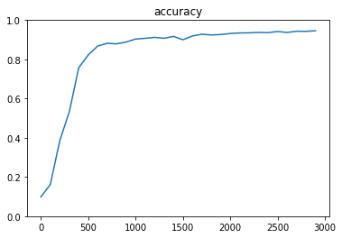

```python
import tensorflow as tf
import numpy as np
from tensorflow.examples.tutorials.mnist import input_data
import matplotlib.pyplot as plt

mnist = input_data.read_data_sets("MNIST_data/", one_hot=True)

iters_num = 3000
batch_size = 100
plot_interval = 100

hidden_layer_size_1 = 600
hidden_layer_size_2 = 300

dropout_rate = 0.5

x = tf.placeholder(tf.float32, [None, 784])
d = tf.placeholder(tf.float32, [None, 10])
W1 = tf.Variable(tf.random_normal([784, hidden_layer_size_1], stddev=0.01))
W2 = tf.Variable(tf.random_normal([hidden_layer_size_1, hidden_layer_size_2], stddev=0.01))
W3 = tf.Variable(tf.random_normal([hidden_layer_size_2, 10], stddev=0.01))

b1 = tf.Variable(tf.zeros([hidden_layer_size_1]))
b2 = tf.Variable(tf.zeros([hidden_layer_size_2]))
b3 = tf.Variable(tf.zeros([10]))

z1 = tf.sigmoid(tf.matmul(x, W1) + b1)
z2 = tf.sigmoid(tf.matmul(z1, W2) + b2)

keep_prob = tf.placeholder(tf.float32)
drop = tf.nn.dropout(z2, keep_prob)

y = tf.nn.softmax(tf.matmul(drop, W3) + b3)
loss = tf.reduce_mean(-tf.reduce_sum(d * tf.log(y), reduction_indices=[1]))


optimizer = tf.train.MomentumOptimizer(0.1, 0.9)


train = optimizer.minimize(loss)
correct = tf.equal(tf.argmax(y, 1), tf.argmax(d, 1))
accuracy = tf.reduce_mean(tf.cast(correct, tf.float32))

init = tf.global_variables_initializer()
sess = tf.Session()
sess.run(init)

accuracies = []
for i in range(iters_num):
    x_batch, d_batch = mnist.train.next_batch(batch_size)
    sess.run(train, feed_dict={x:x_batch, d:d_batch, keep_prob:(1 - dropout_rate)})
    if (i+1) % plot_interval == 0:
        accuracy_val = sess.run(accuracy, feed_dict={x:mnist.test.images, d:mnist.test.labels, keep_prob:1.0})
        accuracies.append(accuracy_val)
        print('Generation: ' + str(i+1) + '. 正解率 = ' + str(accuracy_val))

lists = range(0, iters_num, plot_interval)
plt.plot(lists, accuracies)
plt.title("accuracy")
plt.ylim(0, 1.0)
plt.show()
```

## [try]

- optimizerを変更しよう  
  (AdamをAdagradに変更)

```
Extracting MNIST_data/train-images-idx3-ubyte.gz
Extracting MNIST_data/train-labels-idx1-ubyte.gz
Extracting MNIST_data/t10k-images-idx3-ubyte.gz
Extracting MNIST_data/t10k-labels-idx1-ubyte.gz
Generation: 100. 正解率 = 0.1135
Generation: 200. 正解率 = 0.1135
Generation: 300. 正解率 = 0.1028
Generation: 400. 正解率 = 0.1259
Generation: 500. 正解率 = 0.1637
Generation: 600. 正解率 = 0.2493
Generation: 700. 正解率 = 0.3515
Generation: 800. 正解率 = 0.4838
Generation: 900. 正解率 = 0.5739
Generation: 1000. 正解率 = 0.669
Generation: 1100. 正解率 = 0.731
Generation: 1200. 正解率 = 0.7581
Generation: 1300. 正解率 = 0.7756
Generation: 1400. 正解率 = 0.7986
Generation: 1500. 正解率 = 0.8166
Generation: 1600. 正解率 = 0.8304
Generation: 1700. 正解率 = 0.842
Generation: 1800. 正解率 = 0.8459
Generation: 1900. 正解率 = 0.8577
Generation: 2000. 正解率 = 0.8592
Generation: 2100. 正解率 = 0.8709
Generation: 2200. 正解率 = 0.8705
Generation: 2300. 正解率 = 0.8755
Generation: 2400. 正解率 = 0.8805
Generation: 2500. 正解率 = 0.8874
Generation: 2600. 正解率 = 0.8874
Generation: 2700. 正解率 = 0.8925
Generation: 2800. 正解率 = 0.8916
Generation: 2900. 正解率 = 0.8925
Generation: 3000. 正解率 = 0.8949
```

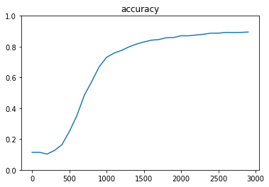

```python
import tensorflow as tf
import numpy as np
from tensorflow.examples.tutorials.mnist import input_data
import matplotlib.pyplot as plt

mnist = input_data.read_data_sets("MNIST_data/", one_hot=True)

iters_num = 3000
batch_size = 100
plot_interval = 100

hidden_layer_size_1 = 600
hidden_layer_size_2 = 300

dropout_rate = 0.5

x = tf.placeholder(tf.float32, [None, 784])
d = tf.placeholder(tf.float32, [None, 10])
W1 = tf.Variable(tf.random_normal([784, hidden_layer_size_1], stddev=0.01))
W2 = tf.Variable(tf.random_normal([hidden_layer_size_1, hidden_layer_size_2], stddev=0.01))
W3 = tf.Variable(tf.random_normal([hidden_layer_size_2, 10], stddev=0.01))

b1 = tf.Variable(tf.zeros([hidden_layer_size_1]))
b2 = tf.Variable(tf.zeros([hidden_layer_size_2]))
b3 = tf.Variable(tf.zeros([10]))

z1 = tf.sigmoid(tf.matmul(x, W1) + b1)
z2 = tf.sigmoid(tf.matmul(z1, W2) + b2)

keep_prob = tf.placeholder(tf.float32)
drop = tf.nn.dropout(z2, keep_prob)

y = tf.nn.softmax(tf.matmul(drop, W3) + b3)
loss = tf.reduce_mean(-tf.reduce_sum(d * tf.log(y), reduction_indices=[1]))


optimizer = tf.train.AdagradOptimizer(0.1)


train = optimizer.minimize(loss)
correct = tf.equal(tf.argmax(y, 1), tf.argmax(d, 1))
accuracy = tf.reduce_mean(tf.cast(correct, tf.float32))

init = tf.global_variables_initializer()
sess = tf.Session()
sess.run(init)

accuracies = []
for i in range(iters_num):
    x_batch, d_batch = mnist.train.next_batch(batch_size)
    sess.run(train, feed_dict={x:x_batch, d:d_batch, keep_prob:(1 - dropout_rate)})
    if (i+1) % plot_interval == 0:
        accuracy_val = sess.run(accuracy, feed_dict={x:mnist.test.images, d:mnist.test.labels, keep_prob:1.0})
        accuracies.append(accuracy_val)
        print('Generation: ' + str(i+1) + '. 正解率 = ' + str(accuracy_val))

lists = range(0, iters_num, plot_interval)
plt.plot(lists, accuracies)
plt.title("accuracy")
plt.ylim(0, 1.0)
plt.show()
```

## [try]

- optimizerを変更しよう  
  (AdamをRMSPropに変更)

```
Extracting MNIST_data/train-images-idx3-ubyte.gz
Extracting MNIST_data/train-labels-idx1-ubyte.gz
Extracting MNIST_data/t10k-images-idx3-ubyte.gz
Extracting MNIST_data/t10k-labels-idx1-ubyte.gz
Generation: 100. 正解率 = 0.1009
Generation: 200. 正解率 = 0.1876
Generation: 300. 正解率 = 0.7408
Generation: 400. 正解率 = 0.8401
Generation: 500. 正解率 = 0.8773
Generation: 600. 正解率 = 0.8965
Generation: 700. 正解率 = 0.9069
Generation: 800. 正解率 = 0.9147
Generation: 900. 正解率 = 0.9203
Generation: 1000. 正解率 = 0.9183
Generation: 1100. 正解率 = 0.931
Generation: 1200. 正解率 = 0.9356
Generation: 1300. 正解率 = 0.936
Generation: 1400. 正解率 = 0.9384
Generation: 1500. 正解率 = 0.9432
Generation: 1600. 正解率 = 0.9454
Generation: 1700. 正解率 = 0.9527
Generation: 1800. 正解率 = 0.9521
Generation: 1900. 正解率 = 0.9516
Generation: 2000. 正解率 = 0.9532
Generation: 2100. 正解率 = 0.951
Generation: 2200. 正解率 = 0.9571
Generation: 2300. 正解率 = 0.9593
Generation: 2400. 正解率 = 0.9609
Generation: 2500. 正解率 = 0.9648
Generation: 2600. 正解率 = 0.9605
Generation: 2700. 正解率 = 0.9646
Generation: 2800. 正解率 = 0.9648
Generation: 2900. 正解率 = 0.9664
Generation: 3000. 正解率 = 0.9671
```

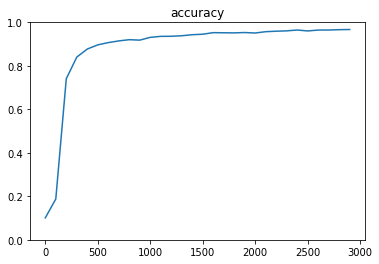

```python
import tensorflow as tf
import numpy as np
from tensorflow.examples.tutorials.mnist import input_data
import matplotlib.pyplot as plt

mnist = input_data.read_data_sets("MNIST_data/", one_hot=True)

iters_num = 3000
batch_size = 100
plot_interval = 100

hidden_layer_size_1 = 600
hidden_layer_size_2 = 300

dropout_rate = 0.5

x = tf.placeholder(tf.float32, [None, 784])
d = tf.placeholder(tf.float32, [None, 10])
W1 = tf.Variable(tf.random_normal([784, hidden_layer_size_1], stddev=0.01))
W2 = tf.Variable(tf.random_normal([hidden_layer_size_1, hidden_layer_size_2], stddev=0.01))
W3 = tf.Variable(tf.random_normal([hidden_layer_size_2, 10], stddev=0.01))

b1 = tf.Variable(tf.zeros([hidden_layer_size_1]))
b2 = tf.Variable(tf.zeros([hidden_layer_size_2]))
b3 = tf.Variable(tf.zeros([10]))

z1 = tf.sigmoid(tf.matmul(x, W1) + b1)
z2 = tf.sigmoid(tf.matmul(z1, W2) + b2)

keep_prob = tf.placeholder(tf.float32)
drop = tf.nn.dropout(z2, keep_prob)

y = tf.nn.softmax(tf.matmul(drop, W3) + b3)
loss = tf.reduce_mean(-tf.reduce_sum(d * tf.log(y), reduction_indices=[1]))


optimizer = tf.train.RMSPropOptimizer(0.001)


train = optimizer.minimize(loss)
correct = tf.equal(tf.argmax(y, 1), tf.argmax(d, 1))
accuracy = tf.reduce_mean(tf.cast(correct, tf.float32))

init = tf.global_variables_initializer()
sess = tf.Session()
sess.run(init)

accuracies = []
for i in range(iters_num):
    x_batch, d_batch = mnist.train.next_batch(batch_size)
    sess.run(train, feed_dict={x:x_batch, d:d_batch, keep_prob:(1 - dropout_rate)})
    if (i+1) % plot_interval == 0:
        accuracy_val = sess.run(accuracy, feed_dict={x:mnist.test.images, d:mnist.test.labels, keep_prob:1.0})
        accuracies.append(accuracy_val)
        print('Generation: ' + str(i+1) + '. 正解率 = ' + str(accuracy_val))

lists = range(0, iters_num, plot_interval)
plt.plot(lists, accuracies)
plt.title("accuracy")
plt.ylim(0, 1.0)
plt.show()
```

## [try]

```
Extracting MNIST_data/train-images-idx3-ubyte.gz
Extracting MNIST_data/train-labels-idx1-ubyte.gz
Extracting MNIST_data/t10k-images-idx3-ubyte.gz
Extracting MNIST_data/t10k-labels-idx1-ubyte.gz
Generation: 100. 正解率 = 0.9161
Generation: 200. 正解率 = 0.9359
Generation: 300. 正解率 = 0.9544
Generation: 400. 正解率 = 0.9585
Generation: 500. 正解率 = 0.9572
Generation: 600. 正解率 = 0.9621
Generation: 700. 正解率 = 0.9673
Generation: 800. 正解率 = 0.9698
Generation: 900. 正解率 = 0.9712
Generation: 1000. 正解率 = 0.965
Generation: 1100. 正解率 = 0.9708
Generation: 1200. 正解率 = 0.9714
Generation: 1300. 正解率 = 0.972
Generation: 1400. 正解率 = 0.9686
Generation: 1500. 正解率 = 0.9723
Generation: 1600. 正解率 = 0.9706
Generation: 1700. 正解率 = 0.9737
Generation: 1800. 正解率 = 0.975
Generation: 1900. 正解率 = 0.9706
Generation: 2000. 正解率 = 0.9726
Generation: 2100. 正解率 = 0.9718
Generation: 2200. 正解率 = 0.9753
Generation: 2300. 正解率 = 0.9723
Generation: 2400. 正解率 = 0.9688
Generation: 2500. 正解率 = 0.974
Generation: 2600. 正解率 = 0.9752
Generation: 2700. 正解率 = 0.9718
Generation: 2800. 正解率 = 0.9763
Generation: 2900. 正解率 = 0.9723
Generation: 3000. 正解率 = 0.9742
```

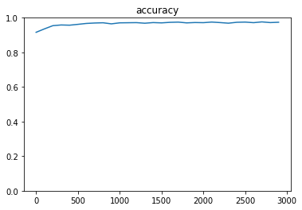

```python
import tensorflow as tf
import numpy as np
from tensorflow.examples.tutorials.mnist import input_data
import matplotlib.pyplot as plt

mnist = input_data.read_data_sets("MNIST_data/", one_hot=True)

iters_num = 3000
batch_size = 100
plot_interval = 100

hidden_layer_size_1 = 600
hidden_layer_size_2 = 300

dropout_rate = 0.5

x = tf.placeholder(tf.float32, [None, 784])
d = tf.placeholder(tf.float32, [None, 10])
W1 = tf.Variable(tf.random_normal([784, hidden_layer_size_1], stddev=0.01))
W2 = tf.Variable(tf.random_normal([hidden_layer_size_1, hidden_layer_size_2], stddev=0.01))
W3 = tf.Variable(tf.random_normal([hidden_layer_size_2, 10], stddev=0.01))

b1 = tf.Variable(tf.zeros([hidden_layer_size_1]))
b2 = tf.Variable(tf.zeros([hidden_layer_size_2]))
b3 = tf.Variable(tf.zeros([10]))

z1 = tf.sigmoid(tf.matmul(x, W1) + b1)
z2 = tf.sigmoid(tf.matmul(z1, W2) + b2)

keep_prob = tf.placeholder(tf.float32)
drop = tf.nn.dropout(z2, keep_prob)

y = tf.nn.softmax(tf.matmul(drop, W3) + b3)
loss = tf.reduce_mean(-tf.reduce_sum(d * tf.log(y), reduction_indices=[1]))


optimizer = tf.train.AdamOptimizer(1e-2)

train = optimizer.minimize(loss)
correct = tf.equal(tf.argmax(y, 1), tf.argmax(d, 1))
accuracy = tf.reduce_mean(tf.cast(correct, tf.float32))

init = tf.global_variables_initializer()
sess = tf.Session()
sess.run(init)

accuracies = []
for i in range(iters_num):
    x_batch, d_batch = mnist.train.next_batch(batch_size)
    sess.run(train, feed_dict={x:x_batch, d:d_batch, keep_prob:(1 - dropout_rate)})
    if (i+1) % plot_interval == 0:
        accuracy_val = sess.run(accuracy, feed_dict={x:mnist.test.images, d:mnist.test.labels, keep_prob:1.0})
        accuracies.append(accuracy_val)
        print('Generation: ' + str(i+1) + '. 正解率 = ' + str(accuracy_val))

lists = range(0, iters_num, plot_interval)
plt.plot(lists, accuracies)
plt.title("accuracy")
plt.ylim(0, 1.0)
plt.show()
```

## 分類CNN (mnist)

conv - relu - pool - conv - relu - pool -  
affin - relu - dropout - affin - softmax

```
Extracting MNIST_data/train-images-idx3-ubyte.gz
Extracting MNIST_data/train-labels-idx1-ubyte.gz
Extracting MNIST_data/t10k-images-idx3-ubyte.gz
Extracting MNIST_data/t10k-labels-idx1-ubyte.gz
Generation: 10. 正解率 = 0.22
Generation: 20. 正解率 = 0.48
Generation: 30. 正解率 = 0.68
Generation: 40. 正解率 = 0.79
Generation: 50. 正解率 = 0.7
Generation: 60. 正解率 = 0.72
Generation: 70. 正解率 = 0.83
Generation: 80. 正解率 = 0.9
Generation: 90. 正解率 = 0.82
Generation: 100. 正解率 = 0.85
Generation: 110. 正解率 = 0.84
Generation: 120. 正解率 = 0.87
Generation: 130. 正解率 = 0.87
Generation: 140. 正解率 = 0.87
Generation: 150. 正解率 = 0.83
Generation: 160. 正解率 = 0.91
Generation: 170. 正解率 = 0.94
Generation: 180. 正解率 = 0.96
Generation: 190. 正解率 = 0.84
Generation: 200. 正解率 = 0.91
Generation: 210. 正解率 = 0.93
Generation: 220. 正解率 = 0.86
Generation: 230. 正解率 = 0.94
Generation: 240. 正解率 = 0.91
Generation: 250. 正解率 = 0.95
Generation: 260. 正解率 = 0.97
Generation: 270. 正解率 = 0.91
Generation: 280. 正解率 = 0.96
Generation: 290. 正解率 = 0.91
Generation: 300. 正解率 = 0.9
```

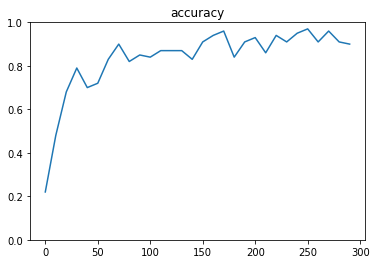

```python
import tensorflow as tf
from tensorflow.examples.tutorials.mnist import input_data
mnist = input_data.read_data_sets("MNIST_data/", one_hot=True)
import matplotlib.pyplot as plt

iters_num = 300
batch_size = 100
plot_interval = 10

dropout_rate = 0.5

# placeholder
x = tf.placeholder(tf.float32, shape=[None, 784])
d = tf.placeholder(tf.float32, shape=[None, 10])

# 画像を784の一次元から28x28の二次元に変換する
# 画像を28x28にreshape
x_image = tf.reshape(x, [-1,28,28,1])#画像n個、28行、28列、1チャンネル

# 第一層のweightsとbiasのvariable
W_conv1 = tf.Variable(tf.truncated_normal([5, 5, 1, 32], stddev=0.1))#5行5列のフィルタ、1チャンネルを32チャンネルに拡張、標準偏差0.01
b_conv1 = tf.Variable(tf.constant(0.1, shape=[32]))

# 第一層のconvolutionalとpool
# strides[0] = strides[3] = 1固定
h_conv1 = tf.nn.relu(tf.nn.conv2d(x_image, W_conv1, strides=[1, 1, 1, 1], padding='SAME') + b_conv1)
# プーリングサイズ n*n にしたい場合 ksize=[1, n, n, 1]
h_pool1 = tf.nn.max_pool(h_conv1, ksize=[1, 2, 2, 1], strides=[1, 2, 2, 1], padding='SAME')

# 第二層
W_conv2 = tf.Variable(tf.truncated_normal([5, 5, 32, 64], stddev=0.1))
b_conv2 = tf.Variable(tf.constant(0.1, shape=[64]))
h_conv2 = tf.nn.relu(tf.nn.conv2d(h_pool1, W_conv2, strides=[1, 1, 1, 1], padding='SAME') + b_conv2)
h_pool2 = tf.nn.max_pool(h_conv2, ksize=[1, 2, 2, 1], strides=[1, 2, 2, 1], padding='SAME')

# 第一層と第二層でreduceされてできた特徴に対してrelu
W_fc1 = tf.Variable(tf.truncated_normal([7 * 7 * 64, 1024], stddev=0.1))
b_fc1 = tf.Variable(tf.constant(0.1, shape=[1024]))
h_pool2_flat = tf.reshape(h_pool2, [-1, 7*7*64])
h_fc1 = tf.nn.relu(tf.matmul(h_pool2_flat, W_fc1) + b_fc1)

# Dropout
keep_prob = tf.placeholder(tf.float32)
h_fc1_drop = tf.nn.dropout(h_fc1, keep_prob)

# 出来上がったものに対してSoftmax
W_fc2 = tf.Variable(tf.truncated_normal([1024, 10], stddev=0.1))
b_fc2 = tf.Variable(tf.constant(0.1, shape=[10]))
y_conv=tf.nn.softmax(tf.matmul(h_fc1_drop, W_fc2) + b_fc2)

# 交差エントロピー
loss = -tf.reduce_sum(d * tf.log(y_conv))

train = tf.train.AdamOptimizer(1e-4).minimize(loss)

correct = tf.equal(tf.argmax(y_conv,1), tf.argmax(d,1))
accuracy = tf.reduce_mean(tf.cast(correct, tf.float32))

init = tf.global_variables_initializer()
sess = tf.Session()
sess.run(init)


accuracies = []
for i in range(iters_num):
    x_batch, d_batch = mnist.train.next_batch(batch_size)
    sess.run(train, feed_dict={x: x_batch, d: d_batch, keep_prob: 1-dropout_rate})
    if (i+1) % plot_interval == 0:
        accuracy_val = sess.run(accuracy, feed_dict={x:x_batch, d: d_batch, keep_prob: 1.0})
        accuracies.append(accuracy_val)
        print('Generation: ' + str(i+1) + '. 正解率 = ' + str(accuracy_val))


lists = range(0, iters_num, plot_interval)
plt.plot(lists, accuracies)
plt.title("accuracy")
plt.ylim(0, 1.0)
plt.show()
```

### [try]

- ドロップアウト率を0に変更しよう

```
Extracting MNIST_data/train-images-idx3-ubyte.gz
Extracting MNIST_data/train-labels-idx1-ubyte.gz
Extracting MNIST_data/t10k-images-idx3-ubyte.gz
Extracting MNIST_data/t10k-labels-idx1-ubyte.gz
Generation: 10. 正解率 = 0.21
Generation: 20. 正解率 = 0.47
Generation: 30. 正解率 = 0.65
Generation: 40. 正解率 = 0.75
Generation: 50. 正解率 = 0.73
Generation: 60. 正解率 = 0.78
Generation: 70. 正解率 = 0.91
Generation: 80. 正解率 = 0.83
Generation: 90. 正解率 = 0.85
Generation: 100. 正解率 = 0.91
Generation: 110. 正解率 = 0.9
Generation: 120. 正解率 = 0.89
Generation: 130. 正解率 = 0.84
Generation: 140. 正解率 = 0.87
Generation: 150. 正解率 = 0.87
Generation: 160. 正解率 = 0.9
Generation: 170. 正解率 = 0.92
Generation: 180. 正解率 = 0.93
Generation: 190. 正解率 = 0.94
Generation: 200. 正解率 = 0.92
Generation: 210. 正解率 = 0.96
Generation: 220. 正解率 = 0.92
Generation: 230. 正解率 = 0.94
Generation: 240. 正解率 = 0.93
Generation: 250. 正解率 = 0.97
Generation: 260. 正解率 = 0.93
Generation: 270. 正解率 = 0.95
Generation: 280. 正解率 = 0.93
Generation: 290. 正解率 = 0.94
Generation: 300. 正解率 = 0.94
```

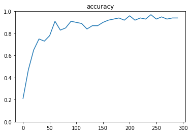

```python
import tensorflow as tf
from tensorflow.examples.tutorials.mnist import input_data
mnist = input_data.read_data_sets("MNIST_data/", one_hot=True)
import matplotlib.pyplot as plt

iters_num = 300
batch_size = 100
plot_interval = 10

dropout_rate = 0

# placeholder
x = tf.placeholder(tf.float32, shape=[None, 784])
d = tf.placeholder(tf.float32, shape=[None, 10])

# 画像を784の一次元から28x28の二次元に変換する
# 画像を28x28にreshape
x_image = tf.reshape(x, [-1,28,28,1])

# 第一層のweightsとbiasのvariable
W_conv1 = tf.Variable(tf.truncated_normal([5, 5, 1, 32], stddev=0.1))
b_conv1 = tf.Variable(tf.constant(0.1, shape=[32]))

# 第一層のconvolutionalとpool
# strides[0] = strides[3] = 1固定
h_conv1 = tf.nn.relu(tf.nn.conv2d(x_image, W_conv1, strides=[1, 1, 1, 1], padding='SAME') + b_conv1)
# プーリングサイズ n*n にしたい場合 ksize=[1, n, n, 1]
h_pool1 = tf.nn.max_pool(h_conv1, ksize=[1, 2, 2, 1], strides=[1, 2, 2, 1], padding='SAME')

# 第二層
W_conv2 = tf.Variable(tf.truncated_normal([5, 5, 32, 64], stddev=0.1))
b_conv2 = tf.Variable(tf.constant(0.1, shape=[64]))
h_conv2 = tf.nn.relu(tf.nn.conv2d(h_pool1, W_conv2, strides=[1, 1, 1, 1], padding='SAME') + b_conv2)
h_pool2 = tf.nn.max_pool(h_conv2, ksize=[1, 2, 2, 1], strides=[1, 2, 2, 1], padding='SAME')

# 第一層と第二層でreduceされてできた特徴に対してrelu
W_fc1 = tf.Variable(tf.truncated_normal([7 * 7 * 64, 1024], stddev=0.1))
b_fc1 = tf.Variable(tf.constant(0.1, shape=[1024]))
h_pool2_flat = tf.reshape(h_pool2, [-1, 7*7*64])
h_fc1 = tf.nn.relu(tf.matmul(h_pool2_flat, W_fc1) + b_fc1)

# Dropout
keep_prob = tf.placeholder(tf.float32)
h_fc1_drop = tf.nn.dropout(h_fc1, keep_prob)

# 出来上がったものに対してSoftmax
W_fc2 = tf.Variable(tf.truncated_normal([1024, 10], stddev=0.1))
b_fc2 = tf.Variable(tf.constant(0.1, shape=[10]))
y_conv=tf.nn.softmax(tf.matmul(h_fc1_drop, W_fc2) + b_fc2)

# 交差エントロピー
loss = -tf.reduce_sum(d * tf.log(y_conv))

train = tf.train.AdamOptimizer(1e-4).minimize(loss)

correct = tf.equal(tf.argmax(y_conv,1), tf.argmax(d,1))
accuracy = tf.reduce_mean(tf.cast(correct, tf.float32))

init = tf.global_variables_initializer()
sess = tf.Session()
sess.run(init)


accuracies = []
for i in range(iters_num):
    x_batch, d_batch = mnist.train.next_batch(batch_size)
    sess.run(train, feed_dict={x: x_batch, d: d_batch, keep_prob: 1-dropout_rate})
    if (i+1) % plot_interval == 0:
        accuracy_val = sess.run(accuracy, feed_dict={x:x_batch, d: d_batch, keep_prob: 1.0})
        accuracies.append(accuracy_val)
        print('Generation: ' + str(i+1) + '. 正解率 = ' + str(accuracy_val))


lists = range(0, iters_num, plot_interval)
plt.plot(lists, accuracies)
plt.title("accuracy")
plt.ylim(0, 1.0)
plt.show()
```